# Association of CAC susceptibility loci plaque characteristics.

A ‘druggable-MI-targets’ project

[Sander W. van der Laan, PhD](https://swvanderlaan.github.io) | @swvanderlaan | s.w.vanderlaan@gmail.com

2020-06-18

# Setup

We will clean the environment, setup the locations, define colors, and create a datestamp.

*Clean the environment.*

*Set locations and working directories…*

```
Create a new analysis directory...
[1] FALSE
[1] FALSE
[1] FALSE
[1] FALSE
[1] FALSE
[1] "/Users/swvanderlaan/PLINK/analyses/lookups/AE_20200512_COL_MKAVOUSI_MBOS_CHARGE_1000G_CAC"
[1] "AE_20200512_COL_MKAVOUSI_MBOS_CHARGE_1000G_CAC.nb.html" "AE_20200512_COL_MKAVOUSI_MBOS_CHARGE_1000G_CAC.Rmd"
[3] "AE_20200512_COL_MKAVOUSI_MBOS_CHARGE_1000G_CAC.Rproj"   "CAC"
[5] "LICENSE"                                                "README.md"
[7] "scRNAseq"                                               "SNP"
```

*… a package-installation function …*

```r
install.packages.auto <- function(x) {
  x <- as.character(substitute(x))
  if (isTRUE(x %in% .packages(all.available = TRUE))) {
    eval(parse(text = sprintf("require(\"%s\")", x)))
  } else {
    # Update installed packages - this may mean a full upgrade of R, which in turn
    # may not be warrented.
    #update.packages(ask = FALSE)
    eval(parse(text = sprintf("install.packages(\"%s\", dependencies = TRUE, repos = \"http://cran-mirror.cs.uu.nl/\")", x)))
  }
  if (isTRUE(x %in% .packages(all.available = TRUE))) {
    eval(parse(text = sprintf("require(\"%s\")", x)))
  } else {
    source("http://bioconductor.org/biocLite.R")
    # Update installed packages - this may mean a full upgrade of R, which in turn
    # may not be warrented.
    #biocLite(character(), ask = FALSE)
    eval(parse(text = sprintf("biocLite(\"%s\")", x)))
    eval(parse(text = sprintf("require(\"%s\")", x)))
  }
}
```

*… and load those packages.*

```r
install.packages.auto("readr")
install.packages.auto("optparse")
install.packages.auto("tools")
install.packages.auto("dplyr")
install.packages.auto("tidyr")
install.packages.auto("naniar")
# To get 'data.table' with 'fwrite' to be able to directly write gzipped-files
# Ref: https://stackoverflow.com/questions/42788401/is-possible-to-use-fwrite-from-data-table-with-gzfile
# install.packages("data.table", repos = "https://Rdatatable.gitlab.io/data.table")
library(data.table)
install.packages.auto("tidyverse")
```

```
x data.table::between() masks dplyr::between()
x data.table::first()   masks dplyr::first()
x data.table::last()    masks dplyr::last()
```

```r
install.packages.auto("knitr")
install.packages.auto("DT")
install.packages.auto("eeptools")
```

```
Welcome to eeptools for R version 1.2.0!
Developed by Jared E. Knowles 2012-2018
for the Wisconsin Department of Public Instruction
Distributed without warranty.
```

```r
install.packages.auto("haven")
install.packages.auto("tableone")
install.packages.auto("BlandAltmanLeh")
# Install the devtools package from Hadley Wickham
install.packages.auto('devtools')
# for plotting
install.packages.auto("pheatmap")
install.packages.auto("forestplot")
install.packages.auto("ggplot2")

install.packages.auto("ggpubr")
install.packages.auto("UpSetR")
devtools::install_github("thomasp85/patchwork")
```

*We will create a datestamp and define the Utrecht Science Park Colour Scheme*.

```r
Today = format(as.Date(as.POSIXlt(Sys.time())), "%Y%m%d")
Today.Report = format(as.Date(as.POSIXlt(Sys.time())), "%A, %B %d, %Y")

### UtrechtScienceParkColoursScheme
###
### WebsitetoconvertHEXtoRGB:http://hex.colorrrs.com.
### Forsomefunctionsyoushoulddividethesenumbersby255.
###
### No. Color                 HEX   (RGB)                                     CHR         MAF/INFO
###---------------------------------------------------------------------------------------
### 1     yellow                #FBB820 (251,184,32)                      =>    1       or 1.0>INFO
### 2     gold                #F59D10 (245,157,16)                    =>    2
### 3     salmon                #E55738 (229,87,56)                   =>    3       or 0.05<MAF<0.2 or 0.4<INFO<0.6
### 4     darkpink          #DB003F ((219,0,63)                   =>    4
### 5     lightpink         #E35493 (227,84,147)                      =>    5       or 0.8<INFO<1.0
### 6     pink                #D5267B (213,38,123)                    =>    6
### 7     hardpink          #CC0071 (204,0,113)                   =>    7
### 8     lightpurple       #A8448A (168,68,138)                      =>    8
### 9     purple                #9A3480 (154,52,128)                      =>    9
### 10  lavendel            #8D5B9A (141,91,154)                      =>    10
### 11  bluepurple        #705296 (112,82,150)                    =>    11
### 12  purpleblue        #686AA9 (104,106,169)               =>    12
### 13  lightpurpleblue #6173AD (97,115,173/101,120,180)    =>  13
### 14  seablue             #4C81BF (76,129,191)                      =>    14
### 15  skyblue             #2F8BC9 (47,139,201)                      =>    15
### 16  azurblue            #1290D9 (18,144,217)                      =>    16      or 0.01<MAF<0.05 or 0.2<INFO<0.4
### 17  lightazurblue     #1396D8 (19,150,216)                    =>    17
### 18  greenblue           #15A6C1 (21,166,193)                      =>    18
### 19  seaweedgreen      #5EB17F (94,177,127)                    =>    19
### 20  yellowgreen       #86B833 (134,184,51)                    =>    20
### 21  lightmossgreen  #C5D220 (197,210,32)                      =>    21
### 22  mossgreen           #9FC228 (159,194,40)                      =>    22      or MAF>0.20 or 0.6<INFO<0.8
### 23  lightgreen      #78B113 (120,177,19)                      =>    23/X
### 24  green                 #49A01D (73,160,29)                     =>    24/Y
### 25  grey                  #595A5C (89,90,92)                        =>  25/XY   or MAF<0.01 or 0.0<INFO<0.2
### 26  lightgrey           #A2A3A4 (162,163,164)                 =>    26/MT
###
### ADDITIONAL COLORS
### 27  midgrey         #D7D8D7
### 28  verylightgrey   #ECECEC"
### 29  white           #FFFFFF
### 30  black           #000000
###----------------------------------------------------------------------------------------------

uithof_color = c("#FBB820","#F59D10","#E55738","#DB003F","#E35493","#D5267B",
                 "#CC0071","#A8448A","#9A3480","#8D5B9A","#705296","#686AA9",
                 "#6173AD","#4C81BF","#2F8BC9","#1290D9","#1396D8","#15A6C1",
                 "#5EB17F","#86B833","#C5D220","#9FC228","#78B113","#49A01D",
                 "#595A5C","#A2A3A4", "#D7D8D7", "#ECECEC", "#FFFFFF", "#000000")

uithof_color_legend = c("#FBB820", "#F59D10", "#E55738", "#DB003F", "#E35493",
                        "#D5267B", "#CC0071", "#A8448A", "#9A3480", "#8D5B9A",
                        "#705296", "#686AA9", "#6173AD", "#4C81BF", "#2F8BC9",
                        "#1290D9", "#1396D8", "#15A6C1", "#5EB17F", "#86B833",
                        "#C5D220", "#9FC228", "#78B113", "#49A01D", "#595A5C",
                        "#A2A3A4", "#D7D8D7", "#ECECEC", "#FFFFFF", "#000000")
### ----------------------------------------------------------------------------
```

# Introduction

## Project details

*Collaborators*

Maryam Kavousi Patricia Peyser Maxime Bos

*Project ID* AE_20200512_COL_MKAVOUSI_MBOS_CHARGE_1000G_CAC

## Background

Here we map the CHARGE Consortium 1000G GWAS on *coronary artery calcification (CAC)* susceptibility loci to the single-cell carotid plaque data. These are given in:

- IndSigSNPsforSander.xlsx
- GeneList_15042020.xlsx

```r
library(openxlsx)

CAC_gene_list <- read.xlsx(paste0(TARGET_loc, "/GeneList_15042020.xlsx"))

CAC_variants <- read.xlsx(paste0(TARGET_loc, "/IndSigSNPsforSander.xlsx"))


DT::datatable(CAC_gene_list)
```

|  | ensg | symbol | chr | start | end | posMapSNPs | eqtlMapSNPs | ciMap | MAGMA | GenomicLocus |
| --- | --- | --- | --- | --- | --- | --- | --- | --- | --- | --- |
| 1 | ENSG00000112137 | PHACTR1 | 6 | 12717893 | 13288645 | 65 | 60 | No | Yes | 1 |
| 2 | ENSG00000078401 | EDN1 | 6 | 12290596 | 12297427 | 0 | 0 | Yes | No | 1 |
| 3 | ENSG00000145990 | GFOD1 | 6 | 13358062 | 13487894 | 0 | 1 | No | No | 1 |
| 4 | ENSG00000145979 | TBC1D7 | 6 | 13266774 | 13328815 | 0 | 7 | No | No | 1 |
| 5 | ENSG00000197594 | ENPP1 | 6 | 132089007 | 132095668 | 1 | 0 | No | No | 2 |
| 6 | ENSG00000154269 | ENPP3 | 6 | 132089007 | 132095668 | 1 | 0 | No | No | 2 |
| 7 | ENSG00000146674 | IGFBP3 | 7 | 45951949 | 45961473 | 12 | 31 | No | Yes | 3 |
| 8 | ENSG00000233539 | AC011294.3 | 7 | 46713383 | 46799449 | 0 | 0 | Yes | No | 3 |
| 9 | ENSG00000224854 | C9orf53 | 9 | 21967137 | 21967738 | 3 | 0 | No | Yes | 4 |
| 10 | ENSG00000147883 | CDKN2B | 9 | 22002902 | 22009362 | 30 | 0 | No | Yes | 4 |

[output cut: 37 more lines]

```r
DT::datatable(CAC_variants)
```

|  | uniqID | rsID | variantid | chr | pos |
| --- | --- | --- | --- | --- | --- |
| 1 | 6:12768218:C:T | rs12202891 | 6:12768218 | 6 | 12768218 |
| 2 | 6:12801967:A:C | rs9381401 | 6:12801967 | 6 | 12801967 |
| 3 | 6:12883524:A:C | rs13208248 | 6:12883524 | 6 | 12883524 |
| 4 | 6:12887465:A:G | rs10456561 | 6:12887465 | 6 | 12887465 |
| 5 | 6:12891103:G:T | rs35355695 | 6:12891103 | 6 | 12891103 |
| 6 | 6:12892486:A:G | rs6925904 | 6:12892486 | 6 | 12892486 |
| 7 | 6:12903957:A:G | rs9349379 | 6:12903957 | 6 | 12903957 |
| 8 | 6:12919867:A:G | rs2876303 | 6:12919867 | 6 | 12919867 |
| 9 | 6:12921714:A:T | rs111395058 | 6:12921714 | 6 | 12921714 |
| 10 | 6:12943066:A:G | rs13201878 | 6:12943066 | 6 | 12943066 |

[output cut: 35 more lines]

```r
NA
```

We will construct a list of genes to map to our scRNAseq data.

```r
CAC_target_genes <- unlist(CAC_gene_list$symbol)
CAC_target_genes
```

```
 [1] "PHACTR1"      "EDN1"         "GFOD1"        "TBC1D7"       "ENPP1"        "ENPP3"        "IGFBP3"       "AC011294.3"
 [9] "C9orf53"      "CDKN2B"       "RP11-145E5.5" "CDKN2A"       "MTAP"         "AL137026.1"   "ZNF32"        "ZNF485"
[17] "ARID5B"       "RTKN2"        "ADK"          "AP3M1"        "CAMK2G"       "COMTD1"       "DUPD1"        "DUSP13"
[25] "KAT6B"        "SAMD8"        "VCL"          "VDAC2"        "FGF23"        "COL4A2"       "ADAMTS7"      "CHRNB4"
[33] "MORF4L1"      "CHRNA5"       "CTSH"         "APOE"         "APOC1"        "BCAM"         "PVRL2"        "TOMM40"
[41] "RPL9"         "C6orf195"     "C12orf4"      "COL4A1"       "CETP"         "SMG6"         "PLEKHJ1"
```

We will test the hypothesis that CAC susceptibility loci are associated with plaque characteristics. We will use data from the Athero-Express Biobank Study.

## Study design

We will perform regression analyses adjusted for age, sex (where applicable) and principal components.

## Modeling

We will apply the following models:

model 1: `phenotype ~ age + sex + chip-used + PC1 + PC2 + year-of-surgery`

phenotypes are:

- `calcification`, coded `Calc.bin` no/minor vs. moderate/heavy staining
- `collagen`, coded `Collagen.bin` no/minor vs. moderate/heavy staining
- `fat10`, coded `Fat.bin_10` no/<10% fat vs. >10% fat
- `fat40`, coded `Fat.bin_40` no/<40% fat vs. >40% fat
- `intraplaque hemorrhage`, coded `IPH.bin` no vs. yes
- `macrophages (CD68)`, coded `macmean0` mean of computer-assisted calculation CD68<sup>+</sup> region of interest
- `smooth muscle cells (alpha-actin)`, coded `smcmean0` mean of computer-assisted calculation SMA<sup>+</sup> region of interest
- `intraplaque vessel density (CD34)`, coded `vessel_density` manually counted CD34<sup>+</sup> cells per 3-4 hotspots
- `mast cells`, coded `Mast_cells_plaque` manually counted mast cell tryptase<sup>+</sup> cells (https://academic.oup.com/eurheartj/article/34/48/3699/484981)
- `neutrophils (CD66b)`, coded `neutrophils` manually counted CD66b<sup>+</sup> cells (https://pubmed.ncbi.nlm.nih.gov/20595650/)

## Athero-Express Biobank Study

The *[Athero-Express Biobank Study (AE)](http://www.atheroexpress.nl)* contains plaque material of patients that underwent endarterectomyat two Dutch tertiary referral centers. Details of the study design were described before. Briefly, blood and plaque material were obtained during endarterectomy and stored at -80 ℃. Only carotid endarterectomy (CEA) patients were included in the present study. All patients provided informed consent and the study was approved by the medical ethics committee.

## Athero-Express Genomics Study

### DNA isolation and genotyping

For the *Athero-Express Genomics Study 1 (AEGS1)* 891 patients (602 males, 262 females, 27 unknown sex), included between 2002 and 2007, were genotyped (440,763 markers) using the Affymetrix Genome-Wide Human SNP Array 5.0 (SNP5) chip (Affymetrix Inc., Santa Clara, CA, USA) at [Eurofins Genomics](https://www.eurofinsgenomics.eu/) (formerly known as AROS).

For the *Athero-Express Genomics Study 2 (AEGS2)* 954 patients (640 makes, 313 females, 1 unknown sex), included between 2002 and 2013, were genotyped (587,351 markers) using the Affymetrix AxiomⓇ GW CEU 1 Array (AxM) at the [Genome Analysis Center](https://www.helmholtz-muenchen.de/no_cache/gac/index.html).

All experiments were carried out according to OECD standards.

### Genotyping calling

We used the genotyping calling algorithms as advised by Affymetrix (AEGS1 and AEGS2) and Illumina (AEGS3):

- AEGS1: BRLMM-P
- AEGS2: AxiomGT1
- AEGS3: Illumina GenomeStudio

### Quality control after genotyping

After genotype calling, we adhered to community standard quality control and assurance (QCA) procedures of the genotype data from AEGS1, AEGS2, and AEGS3. Samples with low average genotype calling and sex discrepancies (compared to the clinical data available) were excluded. The data was further filtered on:

### Imputation

Before phasing using SHAPEIT2, data was lifted to genome build b37 using the liftOver tool from UCSC (https://genome.ucsc.edu/cgi-bin/hgLiftOver). Finally, data was imputed with 1000G phase 3, version 5 and HRC release 1.1 as a reference using the [Michigan Imputation Server](https://imputationserver.sph.umich.edu/). These results were further integrated using QCTOOL v2, where HRC imputed variants are given precendence over 1000G phase 3 imputed variants.

### Quality control after imputation

We compared quality of the three AEGS datasets, and listed some variables of interest.

- sample type (EDTA blood or plaque)
- genotyping chip used
- reason for filtering

We checked the studytype (AE or not), and *identity-by-descent (IBD)* within and between datasets to aid in sample mixups, duplicate sample use, and relatedness. In addition, during genotyping quality control samples were identified that deviated from *Hardy-Weinberg Equilibrium (HWE)*, had discordance in sex-coding and genotype sex, and deviated from the *principal component analysis (PCA)* plot.

We will load the Athero-Express Biobank Study data, and all the samples that were send for genotyping and the final QC’ed sampleList.

## Loading data

Loading Athero-Express Biobank Study clinical and biobank data, as well as the SampleList of genetic data.

```r
cat("* get Athero-Express Biobank Study Database...")
```

```
* get Athero-Express Biobank Study Database...
```

```r
# METHOD 1: It seems this method gives loads of errors and warnings, which all are hard to comprehend
#           or debug. We expect 3,527 samples, and 927 variables; we get 927 variables!!!
# AEdata = as.data.table(read.spss(paste0(INP_loc,"/2017-1NEW_AtheroExpressDatabase_ScientificAE_20171306_v1.0.sav"),
#                                  trim.factor.names = TRUE, trim_values = TRUE, # we trim spaces in values
#                                  reencode = TRUE, # we re-encode to the local locale encoding
#                                  add.undeclared.levels = "append", # we do *not* want to convert to R-factors
#                                  use.value.labels = FALSE, # we do *not* convert variables with value labels into R factors
#                                  use.missings = TRUE, sub = "NA", # we will set every missing variable to NA
#                                  duplicated.value.labels = "condense", # we will condense duplicated value labels
#                                  to.data.frame = TRUE))
# AEdata.labels <- as.data.table(attr(AEdata, "variable.labels"))
# names(AEdata.labels) <- "Variable"

# METHOD 2: Using library("haven") importing seems flawless; best argument being:
#           we expect 3,527 samples and 888 variables, which is what you'd get with this method
#           So for now, METHOD 2 is prefered.
#
require(haven)

AEDB <- haven::read_sav(paste0(AEDB_loc, "/2019-3NEW_AtheroExpressDatabase_ScientificAE_02072019_IC_added.sav"))

# writing off the SPSS data to an Excel.
# fwrite(AEdata, file = paste0(INP_loc,"/2017-1NEW_AtheroExpressDatabase_ScientificAE_20171306_v1.0.values.xlsx"),
#        sep = ";", na = "NA", dec = ".", col.names = TRUE, row.names = FALSE,
#        dateTimeAs = "ISO", showProgress = TRUE, verbose = TRUE)
# warnings()

AEDB[1:10, 1:10]
```

| STUDY_NUMBER | UPID | AE_AAA_bijzonderheden | informedconsent | writtenIC | EZis | date_ic_patient | date_ic_researcher | Hospital | Gender |
| --- | --- | --- | --- | --- | --- | --- | --- | --- | --- |
| 7 | UPID01636 | NA | 1 | 1 | NA | 2002-03-23 | 2002-03-28 | 1 | 1 |
| 1 | UPID04067 | NA | 1 | 1 | NA | 2014-10-09 | 2014-08-15 | 1 | 1 |
| 4 | UPID01863 | NA | 1 | 1 | NA | 2002-03-31 | 2002-03-05 | 1 | 0 |
| 2 | UPID01546 | NA | 1 | 1 | NA | 2002-04-02 | 2002-04-10 | 1 | 1 |
| 6 | UPID00711 | NA | 1 | 1 | NA | 2002-04-03 | 2002-03-08 | 1 | 1 |
| 8 | UPID01052 | NA | 1 | 1 | NA | 2002-04-16 | 2002-04-21 | 1 | 1 |
| 16 | UPID00532 | NA | 1 | 1 | NA | 2002-05-16 | 2002-05-16 | 1 | 0 |
| 3 | UPID01241 | NA | 1 | 1 | NA | 2002-03-25 | 2002-04-21 | 1 | 1 |
| 10 | UPID01934 | NA | 30 | 0 | NA |  |  | 1 | 1 |
| 13 | UPID00678 | NA | 1 | 1 | NA | 2002-04-16 | 2002-04-16 | 1 | 0 |

```r
dim(AEDB)
```

```
[1] 3727 1027
```

```r
cat("* get Athero-Express Genomics Study keys...")
```

```
* get Athero-Express Genomics Study keys...
```

```r
AEGS123.sampleList.keytable <- fread(paste0(AEGSQC_loc, "/QC/SELECTIONS/20200319.QC.AEGS123.sampleList.keytable.txt"))

dim(AEGS123.sampleList.keytable)
```

```
[1] 2124   25
```

```r
# AEGS123.sampleList.keytable[1:10, 1:10]
```

## Fixing and creating variables

We need to be very strict in defining *symptoms.* Therefore we will fix a new variable that groups *symptoms* at inclusion.

Coding of *symptoms* is as follows:

- missing -999
- Asymptomatic 0
- TIA 1
- minor stroke 2
- Major stroke 3
- Amaurosis fugax 4
- Four vessel disease 5
- Vertebrobasilary TIA 7
- Retinal infarction 8
- Symptomatic, but aspecific symtoms 9
- Contralateral symptomatic occlusion 10
- retinal infarction 11
- armclaudication due to occlusion subclavian artery, CEA needed for bypass 12
- retinal infarction + TIAs 13
- Ocular ischemic syndrome 14
- ischemisch glaucoom 15
- subclavian steal syndrome 16
- TGA 17

We will group as follows in `Symptoms.5G`:

1. Asymptomatic > 0
2. TIA > 1, 7, 13
3. Stroke > 2, 3
4. Ocular > 4, 14, 15
5. Retinal infarction > 8, 11
6. Other > 5, 9, 10, 12, 16, 17

We will also group as follows in `AsymptSympt`:

1. Asymptomatic > 0
2. TIA > 1, 7, 13 + Stroke > 2, 3
3. Ocular > 4, 14, 15 + Retinal infarction > 8, 11 + Other > 5, 9, 10, 12, 16, 17

We will also group as follows in `AsymptSympt2G`:

1. Asymptomatic > 0
2. TIA > 1, 7, 13 + Stroke > 2, 3 Ocular > 4, 14, 15 + Retinal infarction > 8, 11 + Other > 5, 9, 10, 12, 16, 17

```r
# Fix symptoms

attach(AEDB)

AEDB$sympt[is.na(AEDB$sympt)] <- -999

# Symptoms.5G
AEDB[,"Symptoms.5G"] <- NA
# AEDB$Symptoms.5G[sympt == "NA"] <- "Asymptomatic"
AEDB$Symptoms.5G[sympt == -999] <- NA
AEDB$Symptoms.5G[sympt == 0] <- "Asymptomatic"
AEDB$Symptoms.5G[sympt == 1 | sympt == 7 | sympt == 13] <- "TIA"
AEDB$Symptoms.5G[sympt == 2 | sympt == 3] <- "Stroke"
AEDB$Symptoms.5G[sympt == 4 | sympt == 14 | sympt == 15 ] <- "Ocular"
AEDB$Symptoms.5G[sympt == 8 | sympt == 11] <- "Retinal infarction"
AEDB$Symptoms.5G[sympt == 5 | sympt == 9 | sympt == 10 | sympt == 12 | sympt == 16 | sympt == 17] <- "Other"

# AsymptSympt
AEDB[,"AsymptSympt"] <- NA
AEDB$AsymptSympt[sympt == -999] <- NA
AEDB$AsymptSympt[sympt == 0] <- "Asymptomatic"
AEDB$AsymptSympt[sympt == 1 | sympt == 7 | sympt == 13 | sympt == 2 | sympt == 3] <- "Symptomatic"
AEDB$AsymptSympt[sympt == 4 | sympt == 14 | sympt == 15 | sympt == 8 | sympt == 11 | sympt == 5 | sympt == 9 | sympt == 10 | sympt == 12 | sympt == 16 | sympt == 17] <- "Ocular and others"

# AsymptSympt
AEDB[,"AsymptSympt2G"] <- NA
AEDB$AsymptSympt2G[sympt == -999] <- NA
AEDB$AsymptSympt2G[sympt == 0] <- "Asymptomatic"
AEDB$AsymptSympt2G[sympt == 1 | sympt == 7 | sympt == 13 | sympt == 2 | sympt == 3 | sympt == 4 | sympt == 14 | sympt == 15 | sympt == 8 | sympt == 11 | sympt == 5 | sympt == 9 | sympt == 10 | sympt == 12 | sympt == 16 | sympt == 17] <- "Symptomatic"

detach(AEDB)

# table(AEDB$sympt, useNA = "ifany")
# table(AEDB$AsymptSympt2G, useNA = "ifany")
# table(AEDB$Symptoms.5G, useNA = "ifany")
#
# table(AEDB$AsymptSympt2G, AEDB$sympt, useNA = "ifany")
# table(AEDB$Symptoms.5G, AEDB$sympt, useNA = "ifany")
table(AEDB$AsymptSympt2G, AEDB$Symptoms.5G, useNA = "ifany")
```

```
               Asymptomatic Ocular Other Retinal infarction Stroke  TIA <NA>
  Asymptomatic          311      0     0                  0      0    0    0
  Symptomatic             0    408   118                 42    720 1030    0
  <NA>                    0      0     0                  0      0    0 1098
```

```r
# AEDB.temp <- subset(AEDB,  select = c("STUDY_NUMBER", "UPID", "Age", "Gender", "Hospital", "Artery_summary", "sympt", "Symptoms.5G", "AsymptSympt"))
# require(labelled)
# AEDB.temp$Gender <- to_factor(AEDB.temp$Gender)
# AEDB.temp$Hospital <- to_factor(AEDB.temp$Hospital)
# AEDB.temp$Artery_summary <- to_factor(AEDB.temp$Artery_summary)
#
# DT::datatable(AEDB.temp[1:10,], caption = "Excerpt of the whole AEDB.", rownames = FALSE)
#
# table(AEDB.temp$Symptoms.5G, AEDB.temp$AsymptSympt)
#
# rm(AEDB.temp)
```

We will also fix the *plaquephenotypes* variable.

Coding of symptoms is as follows:

- missing -999
- not relevant -888
- fibrous 1
- fibroatheromatous 2
- atheromatous 3

```r
# Fix plaquephenotypes
attach(AEDB)
AEDB[,"OverallPlaquePhenotype"] <- NA
AEDB$OverallPlaquePhenotype[plaquephenotype == -999] <- NA
AEDB$OverallPlaquePhenotype[plaquephenotype == -999] <- NA
AEDB$OverallPlaquePhenotype[plaquephenotype == 1] <- "fibrous"
AEDB$OverallPlaquePhenotype[plaquephenotype == 2] <- "fibroatheromatous"
AEDB$OverallPlaquePhenotype[plaquephenotype == 3] <- "atheromatous"
detach(AEDB)

table(AEDB$OverallPlaquePhenotype)
```

```
     atheromatous fibroatheromatous           fibrous
              550               841              1438
```

```r
# AEDB.temp <- subset(AEDB,  select = c("STUDY_NUMBER", "UPID", "Age", "Gender", "Hospital", "Artery_summary", "plaquephenotype", "OverallPlaquePhenotype"))
# require(labelled)
# AEDB.temp$Gender <- to_factor(AEDB.temp$Gender)
# AEDB.temp$Hospital <- to_factor(AEDB.temp$Hospital)
# AEDB.temp$Artery_summary <- to_factor(AEDB.temp$Artery_summary)
#
# DT::datatable(AEDB.temp[1:10,], caption = "Excerpt of the whole AEDB.", rownames = FALSE)
#
# rm(AEDB.temp)
```

We will also fix the *diabetes* status variable. We define diabetes as history of a diagnosis and/or use of glucose-lowering medications.

```r
# Fix diabetes
attach(AEDB)
AEDB[,"DiabetesStatus"] <- NA
AEDB$DiabetesStatus[DM.composite == -999] <- NA
AEDB$DiabetesStatus[DM.composite == 0] <- "Control (no Diabetes Dx/Med)"
AEDB$DiabetesStatus[DM.composite == 1] <- "Diabetes"
detach(AEDB)

table(AEDB$DM.composite)
```

```
   0    1
2745  972
```

```r
table(AEDB$DiabetesStatus)
```

```
Control (no Diabetes Dx/Med)                     Diabetes
                        2745                          972
```

```r
# AEDB.temp <- subset(AEDB,  select = c("STUDY_NUMBER", "UPID", "Age", "Gender", "Hospital", "Artery_summary", "DM.composite", "DiabetesStatus"))
# require(labelled)
# AEDB.temp$Gender <- to_factor(AEDB.temp$Gender)
# AEDB.temp$Hospital <- to_factor(AEDB.temp$Hospital)
# AEDB.temp$Artery_summary <- to_factor(AEDB.temp$Artery_summary)
# AEDB.temp$DiabetesStatus <- to_factor(AEDB.temp$DiabetesStatus)
#
# DT::datatable(AEDB.temp[1:10,], caption = "Excerpt of the whole AEDB.", rownames = FALSE)
#
# rm(AEDB.temp)
```

We will also fix the *smoking* status variable. We are interested in whether someone never, ever or is currently (at the time of inclusion) smoking. This is based on the questionnaire.

- `diet801`: are you a smoker?
- `diet802`: did you smoke in the past?

We already have some variables indicating smoking status:

- `SmokingReported`: patient has reported to smoke.
- `SmokingYearOR`: smoking in the year of surgery?
- `SmokerCurrent`: currently smoking?

```r
require(labelled)
AEDB$diet801 <- to_factor(AEDB$diet801)
AEDB$diet802 <- to_factor(AEDB$diet802)
AEDB$diet805 <- to_factor(AEDB$diet805)
AEDB$SmokingReported <- to_factor(AEDB$SmokingReported)
AEDB$SmokerCurrent <- to_factor(AEDB$SmokerCurrent)
AEDB$SmokingYearOR <- to_factor(AEDB$SmokingYearOR)

# table(AEDB$diet801)
# table(AEDB$diet802)
# table(AEDB$SmokingReported)
# table(AEDB$SmokerCurrent)
# table(AEDB$SmokingYearOR)
# table(AEDB$SmokingReported, AEDB$SmokerCurrent, useNA = "ifany", dnn = c("Reported smoking", "Current smoker"))
#
# table(AEDB$diet801, AEDB$diet802, useNA = "ifany", dnn = c("Smoker", "Past smoker"))

cat("\nFixing smoking status.\n")
```

```
Fixing smoking status.
```

```r
attach(AEDB)
AEDB[,"SmokerStatus"] <- NA
AEDB$SmokerStatus[diet802 == "don't know"] <- "Never smoked"
AEDB$SmokerStatus[diet802 == "I still smoke"] <- "Current smoker"
AEDB$SmokerStatus[SmokerCurrent == "no" & diet802 == "no"] <- "Never smoked"
AEDB$SmokerStatus[SmokerCurrent == "no" & diet802 == "yes"] <- "Ex-smoker"
AEDB$SmokerStatus[SmokerCurrent == "yes"] <- "Current smoker"
AEDB$SmokerStatus[SmokerCurrent == "no data available/missing"] <- NA
# AEDB$SmokerStatus[is.na(SmokerCurrent)] <- "Never smoked"
detach(AEDB)

cat("\n* Current smoking status.\n")
```

```
* Current smoking status.
```

```r
table(AEDB$SmokerCurrent,
      useNA = "ifany",
      dnn = c("Current smoker"))
```

```
Current smoker
no data available/missing                        no                       yes                      <NA>
                        0                      2346                      1302                        79
```

```r
cat("\n* Updated smoking status.\n")
```

```
* Updated smoking status.
```

```r
table(AEDB$SmokerStatus,
      useNA = "ifany",
      dnn = c("Updated smoking status"))
```

```
Updated smoking status
Current smoker      Ex-smoker   Never smoked           <NA>
          1302           1798            387            240
```

```r
cat("\n* Comparing to 'SmokerCurrent'.\n")
```

```
* Comparing to 'SmokerCurrent'.
```

```r
table(AEDB$SmokerStatus, AEDB$SmokerCurrent,
      useNA = "ifany",
      dnn = c("Updated smoking status", "Current smoker"))
```

```
                      Current smoker
Updated smoking status no data available/missing   no  yes <NA>
        Current smoker                         0    0 1302    0
        Ex-smoker                              0 1798    0    0
        Never smoked                           0  387    0    0
        <NA>                                   0  161    0   79
```

```r
# AEDB.temp <- subset(AEDB,  select = c("STUDY_NUMBER", "UPID", "Age", "Gender", "Hospital", "Artery_summary", "DM.composite", "DiabetesStatus"))
# require(labelled)
# AEDB.temp$Gender <- to_factor(AEDB.temp$Gender)
# AEDB.temp$Hospital <- to_factor(AEDB.temp$Hospital)
# AEDB.temp$Artery_summary <- to_factor(AEDB.temp$Artery_summary)
# AEDB.temp$DiabetesStatus <- to_factor(AEDB.temp$DiabetesStatus)
#
# DT::datatable(AEDB.temp[1:10,], caption = "Excerpt of the whole AEDB.", rownames = FALSE)
#
# rm(AEDB.temp)
```

We will also fix the *alcohol* status variable.

```r
# Fix diabetes
attach(AEDB)
AEDB[,"AlcoholUse"] <- NA
AEDB$AlcoholUse[diet810 == -999] <- NA
AEDB$AlcoholUse[diet810 == 0] <- "No"
AEDB$AlcoholUse[diet810 == 1] <- "Yes"
detach(AEDB)

table(AEDB$AlcoholUse)
```

```
  No  Yes
1231 2328
```

```r
# AEDB.temp <- subset(AEDB,  select = c("STUDY_NUMBER", "UPID", "Age", "Gender", "Hospital", "Artery_summary", "diet810", "AlcoholUse"))
# require(labelled)
# AEDB.temp$Gender <- to_factor(AEDB.temp$Gender)
# AEDB.temp$Hospital <- to_factor(AEDB.temp$Hospital)
# AEDB.temp$Artery_summary <- to_factor(AEDB.temp$Artery_summary)
# AEDB.temp$AlcoholUse <- to_factor(AEDB.temp$AlcoholUse)
#
# DT::datatable(AEDB.temp[1:10,], caption = "Excerpt of the whole AEDB.", rownames = FALSE)
#
# rm(AEDB.temp)
```

We will also fix a history of CAD, stroke or peripheral intervention status variable. This will be based on `CAD_history`, `Stroke_history`, and `Peripheral.interv`

```r
# Fix diabetes
attach(AEDB)
AEDB[,"MedHx_CVD"] <- NA
AEDB$MedHx_CVD[CAD_history == 0 | Stroke_history == 0 | Peripheral.interv == 0] <- "No"
AEDB$MedHx_CVD[CAD_history == 1 | Stroke_history == 1 | Peripheral.interv == 1] <- "yes"
detach(AEDB)

table(AEDB$CAD_history)
```

```
   0    1
2387 1266
```

```r
table(AEDB$Stroke_history)
```

```
   0    1
2715  931
```

```r
table(AEDB$Peripheral.interv)
```

```
   0    1
2511 1075
```

```r
table(AEDB$MedHx_CVD)
```

```
  No  yes
1288 2433
```

```r
# AEDB.temp <- subset(AEDB,  select = c("STUDY_NUMBER", "UPID", "Age", "Gender", "Hospital", "Artery_summary", "diet810", "AlcoholUse"))
# require(labelled)
# AEDB.temp$Gender <- to_factor(AEDB.temp$Gender)
# AEDB.temp$Hospital <- to_factor(AEDB.temp$Hospital)
# AEDB.temp$Artery_summary <- to_factor(AEDB.temp$Artery_summary)
# AEDB.temp$AlcoholUse <- to_factor(AEDB.temp$AlcoholUse)
#
# DT::datatable(AEDB.temp[1:10,], caption = "Excerpt of the whole AEDB.", rownames = FALSE)
#
# rm(AEDB.temp)
```

# Athero-Express Biobank Study

## Baseline characteristics

We are interested in the following variables at baseline.

- Age (years)
- Female sex (N, %)
- Hypertension (N, %)
- SBP (mmHg)
- DBP (mmHg)
- Diabetes mellitus (N, %)
- Total cholesterol levels (mg/dL)
- LDL cholesterol levels (mg/dL)
- HDL cholesterol levels (mg/dL)
- Triglyceride levels (mg/dL)
- Use of statins (N, %)
- Use of antiplatelet drugs (N, %)
- BMI (kg/m²)
- Smoking status (N, %)
  - Never smokers
  - Ex-smokers
  - Current smokers
- History of CAD (N, %)
- History of PAD (N, %)
- Clinical manifestations
  - Asymptomatic
  - Amaurosis fugax
  - TIA
  - Stroke
- eGFR (mL/min/1.73 m²)

```r
cat("===========================================================================================\n")
cat("CREATE BASELINE TABLE\n")
```

```
CREATE BASELINE TABLE
```

```r
# Baseline table variables
basetable_vars = c("Hospital", "ORyear",
                   "Age", "Gender",
                   "TC_finalCU", "LDL_finalCU", "HDL_finalCU", "TG_finalCU",
                   "TC_final", "LDL_final", "HDL_final", "TG_final",
                   "systolic", "diastoli", "GFR_MDRD", "BMI",
                   "KDOQI", "BMI_WHO",
                   "SmokerStatus", "AlcoholUse",
                   "DiabetesStatus",
                   "Hypertension.selfreport", "Hypertension.selfreportdrug", "Hypertension.composite", "Hypertension.drugs",
                   "Med.anticoagulants", "Med.all.antiplatelet", "Med.Statin.LLD",
                   "Stroke_Dx", "sympt", "Symptoms.5G", "AsymptSympt",
                   "restenos", "stenose",
                   "MedHx_CVD", "CAD_history", "PAOD", "Peripheral.interv",
                   "EP_composite", "EP_composite_time",
                   "macmean0", "smcmean0", "Macrophages.bin", "SMC.bin",
                   "neutrophils", "Mast_cells_plaque",
                   "IPH.bin", "vessel_density_averaged",
                   "Calc.bin", "Collagen.bin",
                   "Fat.bin_10", "Fat.bin_40", "OverallPlaquePhenotype",
                   "SMC_rankNorm", "MAC_rankNorm", "Neutrophils_rankNorm", "MastCells_rankNorm", "VesselDensity_rankNorm")

basetable_bin = c("Gender",
                  "KDOQI", "BMI_WHO",
                  "SmokerStatus", "AlcoholUse",
                  "DiabetesStatus",
                  "Hypertension.selfreport", "Hypertension.selfreportdrug", "Hypertension.composite", "Hypertension.drugs",
                  "Med.anticoagulants", "Med.all.antiplatelet", "Med.Statin.LLD",
                  "Stroke_Dx", "sympt", "Symptoms.5G", "AsymptSympt",
                  "restenos", "stenose",
                  "CAD_history", "PAOD", "Peripheral.interv",
                  "EP_composite", "Macrophages.bin", "SMC.bin",
                  "IPH.bin",
                  "Calc.bin", "Collagen.bin",
                  "Fat.bin_10", "Fat.bin_40", "OverallPlaquePhenotype")
# basetable_bin

basetable_con = basetable_vars[!basetable_vars %in% basetable_bin]
# basetable_con
```

Showing the baseline table of the whole Athero-Express Biobank.

```r
# Create baseline tables
# http://rstudio-pubs-static.s3.amazonaws.com/13321_da314633db924dc78986a850813a50d5.html
AEDB.tableOne = print(CreateTableOne(vars = basetable_vars,
                                         # factorVars = basetable_bin,
                                         # strata = "Symptoms.4g",
                                         data = AEDB.full, includeNA = TRUE),
                          nonnormal = c(), missing = TRUE,
                          quote = FALSE, noSpaces = FALSE, showAllLevels = TRUE, explain = TRUE,
                          format = "pf",
                          contDigits = 3)[,1:3]
```

```
                                       level                                                                     Overall
  n                                                                                                                 3391
  Hospital % (freq)                    St. Antonius, Nieuwegein                                                     46.2 (1567)
                                       UMC Utrecht                                                                  53.8 (1824)
  ORyear % (freq)                      No data available/missing                                                     0.0 (   0)
                                       2002                                                                          2.5 (  86)
                                       2003                                                                          5.6 ( 191)
                                       2004                                                                          7.8 ( 265)
                                       2005                                                                          8.1 ( 276)
                                       2006                                                                          7.5 ( 254)
                                       2007                                                                          6.1 ( 206)
                                       2008                                                                          5.6 ( 190)
                                       2009                                                                          7.3 ( 246)
                                       2010                                                                          8.2 ( 278)
                                       2011                                                                          7.2 ( 243)
                                       2012                                                                          8.4 ( 284)
                                       2013                                                                          6.9 ( 235)
                                       2014                                                                          8.3 ( 281)
                                       2015                                                                          2.3 (  77)
                                       2016                                                                          3.6 ( 121)
                                       2017                                                                          2.2 (  75)
                                       2018                                                                          1.9 (  65)
                                       2019                                                                          0.5 (  18)
  Age (mean (SD))                                                                                                 68.683 (9.230)
  Gender % (freq)                      female                                                                       29.7 (1006)
                                       male                                                                         70.3 (2385)
  TC_finalCU (mean (SD))                                                                                         184.215 (54.488)
  LDL_finalCU (mean (SD))                                                                                        106.778 (41.000)
  HDL_finalCU (mean (SD))                                                                                         46.573 (16.944)
  TG_finalCU (mean (SD))                                                                                         153.349 (97.240)
  TC_final (mean (SD))                                                                                             4.771 (1.411)
  LDL_final (mean (SD))                                                                                            2.766 (1.062)
  HDL_final (mean (SD))                                                                                            1.206 (0.439)
  TG_final (mean (SD))                                                                                             1.733 (1.099)
  systolic (mean (SD))                                                                                           151.050 (24.992)
  diastoli (mean (SD))                                                                                            80.222 (22.601)
  GFR_MDRD (mean (SD))                                                                                            74.812 (24.352)
  BMI (mean (SD))                                                                                                 26.397 (3.981)
  KDOQI % (freq)                       No data available/missing                                                     0.0 (   0)
                                       Normal kidney function                                                       21.6 ( 734)
```

[output cut: 330 more lines]

```
  Fat.bin_10 % (freq)                  23.9


  Fat.bin_40 % (freq)                  23.9


  OverallPlaquePhenotype % (freq)      24.5



  SMC_rankNorm (mean (SD))             31.6
  MAC_rankNorm (mean (SD))             31.5
  Neutrophils_rankNorm (mean (SD))     90.8
  MastCells_rankNorm (mean (SD))       92.8
  VesselDensity_rankNorm (mean (SD))   47.3
```

```r
# Create baseline tables
# http://rstudio-pubs-static.s3.amazonaws.com/13321_da314633db924dc78986a850813a50d5.html
AEDB.CEA.tableOne = print(CreateTableOne(vars = basetable_vars,
                                         # factorVars = basetable_bin,
                                         # strata = "Symptoms.4g",
                                         data = AEDB.CEA, includeNA = TRUE),
                          nonnormal = c(), missing = TRUE,
                          quote = FALSE, noSpaces = FALSE, showAllLevels = TRUE, explain = TRUE,
                          format = "pf",
                          contDigits = 3)[,1:3]
```

```
                                       level                                                                     Overall
  n                                                                                                                 2388
  Hospital % (freq)                    St. Antonius, Nieuwegein                                                     39.8 ( 951)
                                       UMC Utrecht                                                                  60.2 (1437)
  ORyear % (freq)                      No data available/missing                                                     0.0 (   0)
                                       2002                                                                          3.4 (  81)
                                       2003                                                                          6.6 ( 157)
                                       2004                                                                          8.0 ( 190)
                                       2005                                                                          7.8 ( 186)
                                       2006                                                                          7.7 ( 183)
                                       2007                                                                          6.4 ( 152)
                                       2008                                                                          5.8 ( 139)
                                       2009                                                                          7.7 ( 183)
                                       2010                                                                          6.7 ( 159)
                                       2011                                                                          6.9 ( 165)
                                       2012                                                                          7.5 ( 179)
                                       2013                                                                          6.3 ( 150)
                                       2014                                                                          6.9 ( 164)
                                       2015                                                                          3.2 (  76)
                                       2016                                                                          3.6 (  85)
                                       2017                                                                          2.6 (  63)
                                       2018                                                                          2.6 (  62)
                                       2019                                                                          0.6 (  14)
  Age (mean (SD))                                                                                                 69.119 (9.206)
  Gender % (freq)                      female                                                                       30.4 ( 727)
                                       male                                                                         69.6 (1661)
  TC_finalCU (mean (SD))                                                                                         184.925 (56.512)
  LDL_finalCU (mean (SD))                                                                                        108.611 (41.784)
  HDL_finalCU (mean (SD))                                                                                         46.385 (17.123)
  TG_finalCU (mean (SD))                                                                                         150.824 (91.822)
  TC_final (mean (SD))                                                                                             4.790 (1.464)
  LDL_final (mean (SD))                                                                                            2.813 (1.082)
  HDL_final (mean (SD))                                                                                            1.201 (0.443)
  TG_final (mean (SD))                                                                                             1.704 (1.038)
  systolic (mean (SD))                                                                                           152.714 (25.196)
  diastoli (mean (SD))                                                                                            81.485 (25.318)
  GFR_MDRD (mean (SD))                                                                                            73.022 (21.193)
  BMI (mean (SD))                                                                                                 26.503 (3.957)
  KDOQI % (freq)                       No data available/missing                                                     0.0 (   0)
                                       Normal kidney function                                                       18.8 ( 450)
```

[output cut: 328 more lines]

```
  Fat.bin_10 % (freq)                  22.0


  Fat.bin_40 % (freq)                  22.0


  OverallPlaquePhenotype % (freq)      22.4



  SMC_rankNorm (mean (SD))             28.6
  MAC_rankNorm (mean (SD))             28.4
  Neutrophils_rankNorm (mean (SD))     87.2
  MastCells_rankNorm (mean (SD))       89.9
  VesselDensity_rankNorm (mean (SD))   34.0
```

## Athero-Express Genomics Study: prepare

Let’s combine the full Athero-Express Biobank Study with the key-table containing the AEGS data.

> NOTE: this should sum to 2,124 samples with genotypes.

```r
AEGS <- merge(AEDB.full, AEGS123.sampleList.keytable, by.x = "STUDY_NUMBER", by.y = "STUDY_NUMBER", sort = FALSE,
                  all = TRUE)

dim(AEGS)
```

```
[1] 3504 1066
```

```r
AEGS$UPID.y <- NULL
names(AEGS)[names(AEGS) == "UPID.x"] <- "UPID"
AEGS$Age.y <- NULL
names(AEGS)[names(AEGS) == "Age.x"] <- "Age"

table(AEGS$CHIP, useNA = "ifany")
```

```
AffyAxiomCEU     AffySNP5       IllGSA         <NA>
         918          687          519         1380
```

```r
AEGS$GWAS <- AEGS$CHIP
AEGS$GWAS[is.na(AEGS$GWAS)] <- "not genotyped"
AEGS$GWAS[AEGS$GWAS != "not genotyped"] <- "genotyped"

table(AEGS$CHIP, AEGS$GWAS, useNA = "ifany")
```

```
               genotyped not genotyped
  AffyAxiomCEU       918             0
  AffySNP5           687             0
  IllGSA             519             0
  <NA>                 0          1380
```

Also a visualisation of the AEGS with AEDB overlaps.

```r
library(UpSetR)
require(ggplot2)
require(plyr)
require(gridExtra)
require(grid)

AEDB.availGWAS = list(
AEGS1 = subset(AEGS, CHIP == "AffySNP5", select = c("STUDY_NUMBER"))[,1],
AEGS2 = subset(AEGS, CHIP == "AffyAxiomCEU", select = c("STUDY_NUMBER"))[,1],
AEGS3 = subset(AEGS, CHIP == "IllGSA", select = c("STUDY_NUMBER"))[,1],
AEDB = AEGS$STUDY_NUMBER)

p1 <- UpSetR::upset(fromList(AEDB.availGWAS),
                    sets = c("AEDB", "AEGS1", "AEGS2", "AEGS3"),
                    main.bar.color = c(uithof_color[15], uithof_color[2], uithof_color[3], uithof_color[21]),
                    mainbar.y.label = "intersection sample size",
                    sets.bar.color = c(uithof_color[15], uithof_color[2], uithof_color[3], uithof_color[21]),
                    sets.x.label = "sample size", keep.order = TRUE)
pdf(paste0(PLOT_loc, "/", Today, ".overlap.AEDB_AEGS123.UpSetR.pdf"))
  p1
dev.off()
```

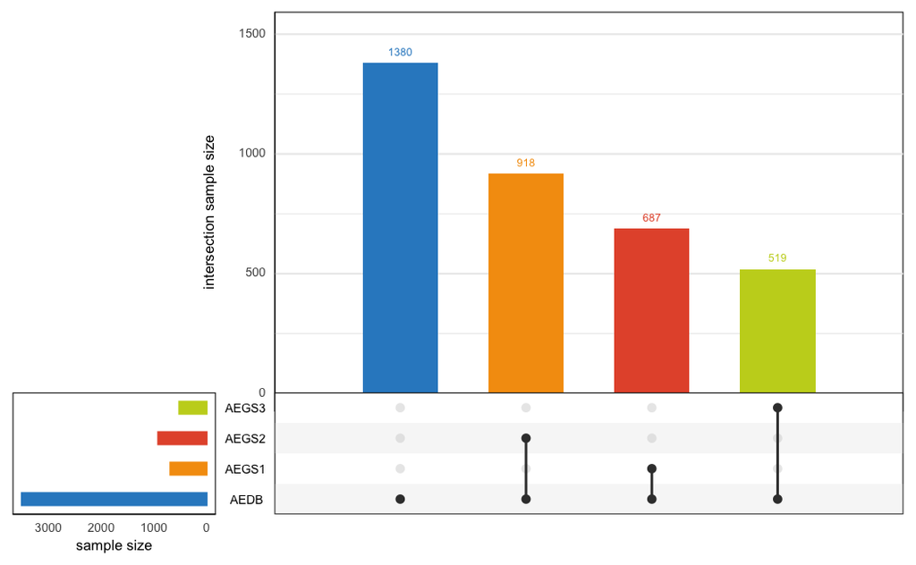

```r
p1
```

```r
rm(p1)
```

```r
table(AEGS$Artery_summary, AEGS$QC2018_FILTER)
```

```
                                                                                          family_discard family_keep issue passed
  No artery known (yet), no surgery (patient ill, died, exited study), re-numbered to AAA              0           0     0      0
  carotid (left & right)                                                                              20          21    40   1819
  femoral/iliac (left, right or both sides)                                                            1           0     0     99
  other carotid arteries (common, external)                                                            0           0     0      9
  carotid bypass and injury (left, right or both sides)                                                0           0     0      1
  aneurysmata (carotid & femoral)                                                                      0           0     0      0
  aorta                                                                                                0           0     0      0
  other arteries (renal, popliteal, vertebral)                                                         0           0     0      1
  femoral bypass, angioseal and injury (left, right or both sides)                                     0           0     0      0
```

```r
table(AEGS$informedconsent, AEGS$QC2018_FILTER)
```

```
                                                                                                  family_discard family_keep issue
  missing                                                                                                      0           0     0
  no, died                                                                                                     0           0     0
  yes                                                                                                         17          16    24
  yes, health treatment when possible                                                                          2           2    10
  yes, no health treatment                                                                                     2           2     2
  yes, no health treatment, no commercial business                                                             0           0     0
  yes, no tissue, no commerical business                                                                       0           0     0
  yes, no tissue, no questionnaires, no medical info, no commercial business                                   0           0     0
  yes, no questionnaires, no health treatment, no commercial business                                          0           0     0
  yes, no questionnaires, health treatment when possible                                                       0           0     0
  yes, no tissue, no questionnaires, no health treatment, no commerical business                               0           0     0
  yes, no health treatment, no medical info, no commercial business                                            0           0     3
  yes, no tissue, no questionnaires, no health treatment, no medical info, no commercial business              0           0     0
  yes, no questionnaires, no health treatment                                                                  0           0     0
  yes, no tissue, no health treatment                                                                          0           0     0
  yes, no tissue, no questionnaires                                                                            0           0     0
  yes, no tissue, health treatment when possible                                                               0           0     0
  yes, no tissue                                                                                               0           0     0
  yes, no commerical business                                                                                  0           1     0
  yes, health treatment when possible, no commercial business                                                  0           0     0
  yes, no medical info, no commercial business                                                                 0           0     0
  yes, no questionnaires                                                                                       0           0     0
  yes, no tissue, no questionnaires, no health treatment, no medical info                                      0           0     0
  yes, no tissue, no questionnaires, no health treatment, no commercial business                               0           0     0
  yes, no medical info                                                                                         0           0     1
  yes, no questionnaires, no commercial business                                                               0           0     0
  yes, no questionnaires, no health treatment, no medical info                                                 0           0     0
  yes, no questionnaires, health treatment when possible, no commercial business                               0           0     0
  yes,  no health treatment, no medical info                                                                   0           0     0
  no, doesn't want to                                                                                          0           0     0
  no, unable to sign                                                                                           0           0     0
  no, no reaction                                                                                              0           0     0
  no, lost                                                                                                     0           0     0
  no, too old                                                                                                  0           0     0
  yes, no medical info, health treatment when possible                                                         0           0     0
  no (never asked for IC because there was no tissue)                                                          0           0     0
  yes, no medical info, no commercial business, health treatment when possible                                 0           0     0
  no, endpoint                                                                                                 0           0     0
  wil niets invullen, wel alles gebruiken                                                                      0           0     0
```

[output cut: 30 more lines]

```
  yes, no questionnaires, no health treatment, no medical info                                         1
  yes, no questionnaires, health treatment when possible, no commercial business                       0
  yes,  no health treatment, no medical info                                                           5
  no, doesn't want to                                                                                  0
  no, unable to sign                                                                                   0
  no, no reaction                                                                                      0
  no, lost                                                                                             0
  no, too old                                                                                          0
  yes, no medical info, health treatment when possible                                                 0
  no (never asked for IC because there was no tissue)                                                  0
  yes, no medical info, no commercial business, health treatment when possible                         2
  no, endpoint                                                                                         0
  wil niets invullen, wel alles gebruiken                                                              7
  second informed concents: yes, no commercial business                                                2
  nooit geincludeerd                                                                                   0
```

```r
AEGSselect <- subset(AEGS,
                     informedconsent != "missing" &
                       informedconsent != "no, died" &
                       informedconsent != "yes, no tissue, no commerical business" &
                       informedconsent != "yes, no tissue, no questionnaires, no medical info, no commercial business" &
                       informedconsent != "yes, no tissue, no questionnaires, no health treatment, no commerical business" &
                       informedconsent != "yes, no tissue, no questionnaires, no health treatment, no medical info, no commercial business" &
                       informedconsent != "yes, no tissue, no health treatment" &
                       informedconsent != "yes, no tissue, no questionnaires" &
                       informedconsent != "yes, no tissue, health treatment when possible" &
                       informedconsent != "yes, no tissue" &
                       informedconsent != "yes, no tissue, no questionnaires, no health treatment, no medical info" &
                       informedconsent != "yes, no tissue, no questionnaires, no health treatment, no commercial business" &
                       informedconsent != "no, doesn't want to" &
                       informedconsent != "no, unable to sign" &
                       informedconsent != "no, no reaction" &
                       informedconsent != "no, lost" &
                       informedconsent != "no, too old" &
                       informedconsent != "yes, no medical info, health treatment when possible" &
                       informedconsent != "no (never asked for IC because there was no tissue)" &
                       informedconsent != "no, endpoint" &
                       informedconsent != "nooit geincludeerd")

AEGSselect.CEA <- subset(AEGS, !is.na(QC2018_FILTER) & QC2018_FILTER != "issue" & QC2018_FILTER != "family_discard" &
                     (Artery_summary == "carotid (left & right)" | Artery_summary == "other carotid arteries (common, external)") & # we only want carotids
                     informedconsent != "missing" &
                       informedconsent != "no, died" &
                       informedconsent != "yes, no tissue, no commerical business" &
                       informedconsent != "yes, no tissue, no questionnaires, no medical info, no commercial business" &
                       informedconsent != "yes, no tissue, no questionnaires, no health treatment, no commerical business" &
                       informedconsent != "yes, no tissue, no questionnaires, no health treatment, no medical info, no commercial business" &
                       informedconsent != "yes, no tissue, no health treatment" &
                       informedconsent != "yes, no tissue, no questionnaires" &
                       informedconsent != "yes, no tissue, health treatment when possible" &
                       informedconsent != "yes, no tissue" &
                       informedconsent != "yes, no tissue, no questionnaires, no health treatment, no medical info" &
                       informedconsent != "yes, no tissue, no questionnaires, no health treatment, no commercial business" &
                       informedconsent != "no, doesn't want to" &
                       informedconsent != "no, unable to sign" &
                       informedconsent != "no, no reaction" &
                       informedconsent != "no, lost" &
                       informedconsent != "no, too old" &
                       informedconsent != "yes, no medical info, health treatment when possible" &
                       informedconsent != "no (never asked for IC because there was no tissue)" &
                       informedconsent != "no, endpoint" &
                       informedconsent != "nooit geincludeerd")

dim(AEGSselect)
```

```
[1] 3391 1065
```

```r
table(AEGSselect$Artery_summary, AEGSselect$QC2018_FILTER)
```

```
                                                                                          family_discard family_keep issue passed
  No artery known (yet), no surgery (patient ill, died, exited study), re-numbered to AAA              0           0     0      0
  carotid (left & right)                                                                              20          21    40   1819
  femoral/iliac (left, right or both sides)                                                            1           0     0     99
  other carotid arteries (common, external)                                                            0           0     0      9
  carotid bypass and injury (left, right or both sides)                                                0           0     0      1
  aneurysmata (carotid & femoral)                                                                      0           0     0      0
  aorta                                                                                                0           0     0      0
  other arteries (renal, popliteal, vertebral)                                                         0           0     0      1
  femoral bypass, angioseal and injury (left, right or both sides)                                     0           0     0      0
```

```r
table(AEGSselect$Artery_summary, AEGSselect$CHIP)
```

```
                                                                                          AffyAxiomCEU AffySNP5 IllGSA
  No artery known (yet), no surgery (patient ill, died, exited study), re-numbered to AAA            0        0      0
  carotid (left & right)                                                                           863      550    487
  femoral/iliac (left, right or both sides)                                                          0       72     28
  other carotid arteries (common, external)                                                          2        5      2
  carotid bypass and injury (left, right or both sides)                                              0        1      0
  aneurysmata (carotid & femoral)                                                                    0        0      0
  aorta                                                                                              0        0      0
  other arteries (renal, popliteal, vertebral)                                                       0        1      0
  femoral bypass, angioseal and injury (left, right or both sides)                                   0        0      0
```

```r
table(AEGSselect$QC2018_FILTER, AEGSselect$CHIP)
```

```
                 AffyAxiomCEU AffySNP5 IllGSA
  family_discard           12        6      3
  family_keep               8        1     12
  issue                    37        1      2
  passed                  808      621    500
```

```r
table(AEGSselect$QC2018_FILTER, AEGSselect$SAMPLE_TYPE)
```

```
                 EDTA blood plaque unknown
  family_discard         15      6       0
  family_keep            13      8       0
  issue                  26     14       0
  passed               1199    729       1
```

```r
AEDB.temp <- subset(AEGSselect,  select = c("STUDY_NUMBER", "UPID", "Age", "Gender", "Hospital", "Artery_summary", "QC2018_FILTER", "CHIP", "SAMPLE_TYPE"))
require(labelled)
AEDB.temp$Gender <- to_factor(AEDB.temp$Gender)
AEDB.temp$Hospital <- to_factor(AEDB.temp$Hospital)
AEDB.temp$Artery_summary <- to_factor(AEDB.temp$Artery_summary)
AEDB.temp$QC2018_FILTER <- to_factor(AEDB.temp$QC2018_FILTER)
AEDB.temp$CHIP <- to_factor(AEDB.temp$CHIP)
AEDB.temp$SAMPLE_TYPE <- to_factor(AEDB.temp$SAMPLE_TYPE)

DT::datatable(AEDB.temp[1:10,], caption = "Excerpt of the whole AEDB.", rownames = FALSE)
```

| STUDY_NUMBER | UPID | Age | Gender | Hospital | Artery_summary | QC2018_FILTER | CHIP | SAMPLE_TYPE |
| --- | --- | --- | --- | --- | --- | --- | --- | --- |
| 7 | UPID01636 | 63 | male | St. Antonius, Nieuwegein | carotid (left &amp; right) | passed | AffySNP5 | EDTA blood |
| 1 | UPID04067 | 63 | male | St. Antonius, Nieuwegein | carotid (left &amp; right) | issue | AffySNP5 | EDTA blood |
| 4 | UPID01863 | 79 | female | St. Antonius, Nieuwegein | carotid (left &amp; right) | passed | AffySNP5 | EDTA blood |
| 6 | UPID00711 | 68 | male | St. Antonius, Nieuwegein | carotid (left &amp; right) | passed | AffyAxiomCEU | EDTA blood |
| 8 | UPID01052 | 66 | male | St. Antonius, Nieuwegein | carotid (left &amp; right) | passed | AffySNP5 | EDTA blood |
| 16 | UPID00532 | 70 | female | St. Antonius, Nieuwegein | carotid (left &amp; right) | passed | AffyAxiomCEU | plaque |
| 13 | UPID00678 | 60 | female | St. Antonius, Nieuwegein | carotid (left &amp; right) | passed | AffySNP5 | EDTA blood |
| 5 | UPID00636 | 68 | male | St. Antonius, Nieuwegein | carotid (left &amp; right) | passed | AffyAxiomCEU | EDTA blood |
| 11 | UPID01326 | 63 | male | St. Antonius, Nieuwegein | carotid (left &amp; right) | passed | AffySNP5 | EDTA blood |
| 9 | UPID00918 | 74 | male | St. Antonius, Nieuwegein | carotid (left &amp; right) | passed | AffySNP5 | EDTA blood |

```r
rm(AEDB.temp)
```

## Athero-Express Genomics Study: baseline characteristics

Showing the baseline table of the Athero-Express Genomics Study.

```r
# Create baseline tables
# http://rstudio-pubs-static.s3.amazonaws.com/13321_da314633db924dc78986a850813a50d5.html
AEGSselect$GWAS <- to_factor(AEGSselect$GWAS)
AEGSselect$CHIP <- to_factor(AEGSselect$CHIP)
AEGSselect$PCA <- to_factor(AEGSselect$PCA)
AEGSselect$SAMPLE_TYPE <- to_factor(AEGSselect$SAMPLE_TYPE)
AEGSselect$informedconsent <- to_factor(AEGSselect$informedconsent)

AEGSselect.CEA$GWAS <- to_factor(AEGSselect.CEA$GWAS)
AEGSselect.CEA$CHIP <- to_factor(AEGSselect.CEA$CHIP)
AEGSselect.CEA$PCA <- to_factor(AEGSselect.CEA$PCA)
AEGSselect.CEA$SAMPLE_TYPE <- to_factor(AEGSselect.CEA$SAMPLE_TYPE)
AEGSselect.CEA$informedconsent <- to_factor(AEGSselect.CEA$informedconsent)


cat("===========================================================================================\n")
cat("CREATE BASELINE TABLE\n")
```

```
CREATE BASELINE TABLE
```

```r
# Baseline table variables
basetable_vars = c("Hospital",
                   "Age", "Gender",
                   "TC_final", "LDL_final", "HDL_final", "TG_final",
                   "systolic", "diastoli", "GFR_MDRD", "BMI",
                   "KDOQI", "BMI_WHO",
                   "SmokerCurrent", "eCigarettes", "ePackYearsSmoking",
                   "DiabetesStatus", "Hypertension.selfreport", "Hypertension.selfreportdrug", "Hypertension.composite",
                   "Hypertension.drugs", "Med.anticoagulants", "Med.all.antiplatelet", "Med.Statin.LLD",
                   "Stroke_Dx", "sympt", "Symptoms.5G", "restenos",
                   "EP_composite", "EP_composite_time",
                   "macmean0", "smcmean0", "Macrophages.bin", "SMC.bin", "neutrophils", "Mast_cells_plaque", "vessel_density_averaged",
                   "IPH.bin",
                   "Calc.bin", "Collagen.bin",
                   "Fat.bin_10", "Fat.bin_40", "OverallPlaquePhenotype",
                   "SMC_rankNorm", "MAC_rankNorm", "Neutrophils_rankNorm", "MastCells_rankNorm", "VesselDensity_rankNorm",
                  "GWAS", "CHIP", "PCA")

basetable_bin = c("Gender",
                  "KDOQI", "BMI_WHO",
                  "SmokerCurrent",
                  "DiabetesStatus", "Hypertension.selfreport", "Hypertension.selfreportdrug", "Hypertension.composite",
                  "Hypertension.drugs", "Med.anticoagulants", "Med.all.antiplatelet", "Med.Statin.LLD",
                  "Stroke_Dx", "sympt", "Symptoms.5G", "restenos",
                  "EP_composite", "Macrophages.bin", "SMC.bin",
                  "IPH.bin",
                  "Calc.bin", "Collagen.bin",
                  "Fat.bin_10", "Fat.bin_40", "OverallPlaquePhenotype",
                  "GWAS", "CHIP", "PCA")

basetable_bin
```

```
 [1] "Gender"                      "KDOQI"                       "BMI_WHO"                     "SmokerCurrent"
 [5] "DiabetesStatus"              "Hypertension.selfreport"     "Hypertension.selfreportdrug" "Hypertension.composite"
 [9] "Hypertension.drugs"          "Med.anticoagulants"          "Med.all.antiplatelet"        "Med.Statin.LLD"
[13] "Stroke_Dx"                   "sympt"                       "Symptoms.5G"                 "restenos"
[17] "EP_composite"                "Macrophages.bin"             "SMC.bin"                     "IPH.bin"
[21] "Calc.bin"                    "Collagen.bin"                "Fat.bin_10"                  "Fat.bin_40"
[25] "OverallPlaquePhenotype"      "GWAS"                        "CHIP"                        "PCA"
```

```r
basetable_con = basetable_vars[!basetable_vars %in% basetable_bin]
basetable_con
```

```
 [1] "Hospital"                "Age"                     "TC_final"                "LDL_final"               "HDL_final"
 [6] "TG_final"                "systolic"                "diastoli"                "GFR_MDRD"                "BMI"
[11] "eCigarettes"             "ePackYearsSmoking"       "EP_composite_time"       "macmean0"                "smcmean0"
[16] "neutrophils"             "Mast_cells_plaque"       "vessel_density_averaged" "SMC_rankNorm"            "MAC_rankNorm"
[21] "Neutrophils_rankNorm"    "MastCells_rankNorm"      "VesselDensity_rankNorm"
```

All Athero-Express Genomics Study data (n = 2,011), compared to the *remaining*, _un_genotyped Athero-Express Biobank Study.

```r
cat("\n===========================================================================================\n")
cat("DISPLAY BASELINE TABLE\n")

AEGSselect.tableOne = print(CreateTableOne(vars = basetable_vars,
                                         # factorVars = basetable_bin,
                                         strata = "GWAS",
                                         data = AEGSselect, includeNA = TRUE),
                          nonnormal = c(), missing = TRUE,
                          quote = FALSE, noSpaces = FALSE, showAllLevels = TRUE, explain = TRUE,
                          format = "pf",
                          contDigits = 3)[,1:6]
```

[output not shown]

Baseline of the valid, CEA and genotyped data.

```r
AEGSselect.CEA.tableOne = print(CreateTableOne(vars = basetable_vars,
                                         # factorVars = basetable_bin,
                                         strata = "Gender",
                                         data = AEGSselect.CEA, includeNA = TRUE),
                          nonnormal = c(), missing = TRUE,
                          quote = FALSE, noSpaces = FALSE, showAllLevels = TRUE, explain = TRUE,
                          format = "pf",
                          contDigits = 3)[,1:6]
```

[output not shown]

## Athero-Express Genomics Study: writing

Let’s save the baseline characteristics of the Athero-Express Genomics Study.

```r
# Write basetable
require(openxlsx)

write.xlsx(file = paste0(BASELINE_loc, "/",Today,".",PROJECTNAME,".AEGS.BaselineTable.xlsx"),
           AEGSselect.tableOne,
           row.names = TRUE,
           col.names = TRUE,
           sheetName = "AEGS_Baseline")

write.xlsx(file = paste0(BASELINE_loc, "/",Today,".",PROJECTNAME,".AEGS.CEA.BaselineTable.xlsx"),
           AEGSselect.CEA.tableOne,
           row.names = TRUE,
           col.names = TRUE,
           sheetName = "AEGS_Baseline_full")
```

# SampleLists

## Autosomal data.

We are ready to make a sampleList for use with the imputed data.

```r
require(openxlsx)

temp <- subset(AEGS,
               GWAS == "genotyped",
               select = c("ID_1", "ID_2", "UPID", "STUDY_NUMBER", # ID_2 is the order of samples!
                          "QC2018_FINAL", "QC2018_FILTER", "OriginalOrder_postMichImp_QC",
                          "AEGS_type", "CHIP", "STUDY_TYPE", "SAMPLE_TYPE", "PCA",
                          "PC1", "PC2", "PC3", "PC4", "PC5",
                          "PC6", "PC7", "PC8", "PC9", "PC10",
                          "Sex", "Age", "ORyear",
                          "Calc.bin", "Collagen.bin",
                          "Fat.bin_10", "Fat.bin_40", "IPH.bin",
                          "SMC_rankNorm", "MAC_rankNorm", "Neutrophils_rankNorm", "MastCells_rankNorm", "VesselDensity_rankNorm",
                          "OverallPlaquePhenotype")) # Select some phenotype of interest
dim(temp)
```

```
[1] 2124   36
```

```r
# Fix things
attach(temp)

temp[,"Calcification"] <- NA
temp$Calcification[Calc.bin == "no/minor"] <- "control"
temp$Calcification[Calc.bin == "moderate/heavy"] <- "case"

temp[,"Collagen"] <- NA
temp$Collagen[Collagen.bin == "no/minor"] <- "control"
temp$Collagen[Collagen.bin == "moderate/heavy"] <- "case"

temp[,"Fat10"] <- NA
temp$Fat10[Fat.bin_10 == "<10%"] <- "control"
temp$Fat10[Fat.bin_10 == ">10%"] <- "case"

temp[,"Fat40"] <- NA
temp$Fat40[Fat.bin_40 == "<40%"] <- "control"
temp$Fat40[Fat.bin_40 == ">40%"] <- "case"

temp[,"IPH"] <- NA
temp$IPH[IPH.bin == "no"] <- "control"
temp$IPH[IPH.bin == "yes"] <- "case"

detach(temp)

# Making selection variable
attach(temp)
temp[,"SELECTION"] <- "not_selected"
temp$SELECTION[(QC2018_FILTER=="passed" | QC2018_FILTER=="family_keep") & (STUDY_TYPE=="CEA" & PCA=="EUR")] <- "selected"
detach(temp)
table(temp$SELECTION, temp$QC2018_FILTER)
```

```
               family_discard family_keep issue passed
  not_selected             23           0    40    153
  selected                  0          21     0   1887
```

```r
table(temp$SELECTION, temp$STUDY_TYPE)
```

```
                CEA  FEA Other
  not_selected   94  109    12
  selected     1908    0     0
```

```r
table(temp$SELECTION, temp$PCA)
```

```
                EUR nonEUR
  not_selected  167     45
  selected     1908      0
```

```r
AEGS123_sample.list <- temp[order(temp$OriginalOrder_postMichImp_QC),]

AEGS123_sample.list$missing <- 0

sample_file_aegs <- dplyr::select(AEGS123_sample.list,
                                  ID_1, ID_2, missing, # ID_2 is the order of samples - that way we always know what the order should be
                                  UPID, STUDY_NUMBER,
                                  QC2018_FINAL, QC2018_FILTER, SELECTION,
                                  AEGS_type, CHIP, STUDY_TYPE, SAMPLE_TYPE, PCA,
                                  PC1, PC2, PC3, PC4, PC5, PC6, PC7, PC8, PC9, PC10,
                                  Sex, Age, ORyear,
                                  Calcification, Collagen,
                                  Fat10, Fat40, IPH,
                                  SMC_rankNorm, MAC_rankNorm, Neutrophils_rankNorm, MastCells_rankNorm, VesselDensity_rankNorm,
                                  OverallPlaquePhenotype)  %>%
  mutate_if(is.numeric, as.character) %>%
  mutate(SAMPLE_TYPE = gsub(' ', '_', SAMPLE_TYPE)) %>%
  add_row(.before = 1,
          ID_1 = "0", ID_2 = "0", missing = "0",
          UPID = "D", STUDY_NUMBER = "C",
          QC2018_FINAL = "D", QC2018_FILTER = "D", SELECTION = "D",
          AEGS_type = "D", CHIP = "D", STUDY_TYPE = "D", SAMPLE_TYPE = "D", PCA = "D",
          PC1 = "C", PC2 = "C", PC3 = "C", PC4 = "C", PC5 = "C", PC6 = "C", PC7 = "C", PC8 = "C", PC9 = "C", PC10 = "C",
          Sex = "D", Age = "C", ORyear = "C",
          Calcification = "B", Collagen = "B",
          Fat10 = "B", Fat40 = "B", IPH = "B",
          SMC_rankNorm = "P", MAC_rankNorm = "P", Neutrophils_rankNorm = "P", MastCells_rankNorm = "P", VesselDensity_rankNorm = "P",
          OverallPlaquePhenotype = "B") %>% ## identifiers: index for these is 1, and all base variables have 0 as identifier
  print()
```

| ID_1 | ID_2 | missing | UPID | STUDY_NUMBER | QC2018_FINAL | QC2018_FILTER | SELECTION | AEGS_type | CHIP | STUDY_TYPE | SAMPLE_TYPE | PCA | PC1 | PC2 | PC3 | PC4 | PC5 | PC6 | PC7 | PC8 | PC9 | PC10 | Sex | Age | ORyear | Calcification | Collagen | Fat10 | Fat40 | … |
| --- | --- | --- | --- | --- | --- | --- | --- | --- | --- | --- | --- | --- | --- | --- | --- | --- | --- | --- | --- | --- | --- | --- | --- | --- | --- | --- | --- | --- | --- | --- |
| 0 | 0 | 0 | D | C | D | D | D | D | D | D | D | D | C | C | C | C | C | C | C | C | C | C | D | C | C | B | B | B | B | … |
| UPID01043-UPID01043-A318-0006 | 1 | 0 | UPID01043 | 1489 | NA | passed | selected | AEGS1 | AffySNP5 | CEA | EDTA_blood | EUR | 0.0028 | -0.0116 | 0.0397 | 0.0144 | -0.0197 | 0.0231 | -0.0032 | -0.0221 | 0.0123 | 0.012 | M | 70 | 2006 | case | case | NA | control | … |
| UPID00749-UPID00749-A318-0008 | 2 | 0 | UPID00749 | 1576 | NA | passed | selected | AEGS1 | AffySNP5 | CEA | EDTA_blood | EUR | 0.0049 | 0.0073 | -0.0376 | 0.025 | 0.0077 | -0.0243 | 0.0123 | 0.0176 | -0.0344 | -0.0112 | F | 58 | 2007 | case | case | NA | control | … |
| UPID01788-UPID01788-A318-0009 | 3 | 0 | UPID01788 | 738 | NA | passed | selected | AEGS1 | AffySNP5 | CEA | plaque | EUR | 0.0128 | 0.0159 | 0.0253 | -0.011 | -0.0144 | 0.007 | 0.0296 | 0 | -0.0243 | 0.0113 | M | 57 | 2005 | control | case | NA | case | … |
| UPID00338-UPID00338-A318-0011 | 4 | 0 | UPID00338 | 62 | NA | passed | selected | AEGS1 | AffySNP5 | CEA | plaque | EUR | 0.0178 | 0.0453 | 0.0026 | -0.0029 | -0.0215 | 0.039 | -0.0083 | -0.007 | -0.0071 | -0.0033 | M | 71 | 2003 | case | case | NA | control | … |
| UPID00166-UPID00166-A318-0012 | 5 | 0 | UPID00166 | 33 | NA | passed | selected | AEGS1 | AffySNP5 | CEA | plaque | EUR | -0.0493 | 0.022 | 0.0135 | 0.012 | 0.0125 | -0.0227 | 0.0163 | 0.0328 | -0.0624 | -0.025 | M | 69 | 2003 | case | case | NA | control | … |
| UPID00205-UPID00205-A318-0013 | 6 | 0 | UPID00205 | 607 | NA | passed | selected | AEGS1 | AffySNP5 | CEA | plaque | EUR | 0.0136 | -0.0034 | 0.0242 | 0.0081 | -0.0223 | 0.017 | -0.0031 | -0.0181 | -0.018 | -0.0123 | M | 67 | 2005 | case | case | NA | control | … |
| UPID00443-UPID00443-A318-0014 | 7 | 0 | UPID00443 | 595 | NA | passed | selected | AEGS1 | AffySNP5 | CEA | plaque | EUR | 0.0304 | 0.0214 | -0.0176 | -0.0082 | -0.003 | -0.0124 | -0.0183 | 0.0063 | -0.0185 | -0.023 | M | 60 | 2004 | case | case | NA | case | … |
| UPID00444-UPID00444-A318-0016 | 8 | 0 | UPID00444 | 1025 | NA | passed | selected | AEGS1 | AffySNP5 | CEA | plaque | EUR | -0.0343 | 0.0016 | 0.0392 | 0.0179 | 0.0158 | 0.0189 | 0.0328 | -0.0167 | 0.0231 | 0.0065 | M | 63 | 2005 | case | case | NA | case | … |
| UPID01884-UPID01884-A318-0017 | 9 | 0 | UPID01884 | 872 | NA | passed | selected | AEGS1 | AffySNP5 | CEA | plaque | EUR | 0.0193 | -0.0226 | -0.0253 | 0.0189 | 0.0021 | 0.0072 | 0.0139 | -0.0124 | 0.0089 | -0.0155 | M | 64 | 2005 | control | control | NA | case | … |

[output cut: 990 more lines]

```r
dim(sample_file_aegs)
```

```
[1] 2125   37
```

```r
fwrite(sample_file_aegs,
       file = paste0(OUT_loc, "/",Today,".",PROJECTNAME,".AEGS123.sample"),
       na = "NA", sep = "\t", quote = FALSE,
       row.names = FALSE, col.names = TRUE,
       showProgress = TRUE, verbose = TRUE)
```

[output not shown]

```r
require(DT)
DT::datatable(sample_file_aegs, caption = "AEGS: final sample list of genotyped AE patients after quality control.", rownames = FALSE)
```

```
It seems your data is too big for client-side DataTables. You may consider server-side processing: https://rstudio.github.io/DT/server.htmlIt seems your data is too big for client-side DataTables. You may consider server-side processing: https://rstudio.github.io/DT/server.html
```

| ID_1 | ID_2 | missing | UPID | STUDY_NUMBER | QC2018_FINAL | QC2018_FILTER | SELECTION | AEGS_type | CHIP | STUDY_TYPE | SAMPLE_TYPE | PCA | PC1 | PC2 | PC3 | PC4 | PC5 | PC6 | PC7 | PC8 | PC9 | PC10 | Sex | Age | ORyear | Calcification | Collagen | Fat10 | Fat40 | … |
| --- | --- | --- | --- | --- | --- | --- | --- | --- | --- | --- | --- | --- | --- | --- | --- | --- | --- | --- | --- | --- | --- | --- | --- | --- | --- | --- | --- | --- | --- | --- |
| 0 | 0 | 0 | D | C | D | D | D | D | D | D | D | D | C | C | C | C | C | C | C | C | C | C | D | C | C | B | B | B | B | … |
| UPID01043-UPID01043-A318-0006 | 1 | 0 | UPID01043 | 1489 |  | passed | selected | AEGS1 | AffySNP5 | CEA | EDTA_blood | EUR | 0.0028 | -0.0116 | 0.0397 | 0.0144 | -0.0197 | 0.0231 | -0.0032 | -0.0221 | 0.0123 | 0.012 | M | 70 | 2006 | case | case |  | control | … |
| UPID00749-UPID00749-A318-0008 | 2 | 0 | UPID00749 | 1576 |  | passed | selected | AEGS1 | AffySNP5 | CEA | EDTA_blood | EUR | 0.0049 | 0.0073 | -0.0376 | 0.025 | 0.0077 | -0.0243 | 0.0123 | 0.0176 | -0.0344 | -0.0112 | F | 58 | 2007 | case | case |  | control | … |
| UPID01788-UPID01788-A318-0009 | 3 | 0 | UPID01788 | 738 |  | passed | selected | AEGS1 | AffySNP5 | CEA | plaque | EUR | 0.0128 | 0.0159 | 0.0253 | -0.011 | -0.0144 | 0.007 | 0.0296 | 0 | -0.0243 | 0.0113 | M | 57 | 2005 | control | case |  | case | … |
| UPID00338-UPID00338-A318-0011 | 4 | 0 | UPID00338 | 62 |  | passed | selected | AEGS1 | AffySNP5 | CEA | plaque | EUR | 0.0178 | 0.0453 | 0.0026 | -0.0029 | -0.0215 | 0.039 | -0.0083 | -0.007 | -0.0071 | -0.0033 | M | 71 | 2003 | case | case |  | control | … |
| UPID00166-UPID00166-A318-0012 | 5 | 0 | UPID00166 | 33 |  | passed | selected | AEGS1 | AffySNP5 | CEA | plaque | EUR | -0.0493 | 0.022 | 0.0135 | 0.012 | 0.0125 | -0.0227 | 0.0163 | 0.0328 | -0.0624 | -0.025 | M | 69 | 2003 | case | case |  | control | … |
| UPID00205-UPID00205-A318-0013 | 6 | 0 | UPID00205 | 607 |  | passed | selected | AEGS1 | AffySNP5 | CEA | plaque | EUR | 0.0136 | -0.0034 | 0.0242 | 0.0081 | -0.0223 | 0.017 | -0.0031 | -0.0181 | -0.018 | -0.0123 | M | 67 | 2005 | case | case |  | control | … |
| UPID00443-UPID00443-A318-0014 | 7 | 0 | UPID00443 | 595 |  | passed | selected | AEGS1 | AffySNP5 | CEA | plaque | EUR | 0.0304 | 0.0214 | -0.0176 | -0.0082 | -0.003 | -0.0124 | -0.0183 | 0.0063 | -0.0185 | -0.023 | M | 60 | 2004 | case | case |  | case | … |
| UPID00444-UPID00444-A318-0016 | 8 | 0 | UPID00444 | 1025 |  | passed | selected | AEGS1 | AffySNP5 | CEA | plaque | EUR | -0.0343 | 0.0016 | 0.0392 | 0.0179 | 0.0158 | 0.0189 | 0.0328 | -0.0167 | 0.0231 | 0.0065 | M | 63 | 2005 | case | case |  | case | … |
| UPID01884-UPID01884-A318-0017 | 9 | 0 | UPID01884 | 872 |  | passed | selected | AEGS1 | AffySNP5 | CEA | plaque | EUR | 0.0193 | -0.0226 | -0.0253 | 0.0189 | 0.0021 | 0.0072 | 0.0139 | -0.0124 | 0.0089 | -0.0155 | M | 64 | 2005 | control | control |  | case | … |

[output cut: 2115 more lines]

```r
rm(temp, temp2, temp3)
```

```
object 'temp2' not foundobject 'temp3' not found
```

## X-chromosome data

The X-chromosome data is taken from previously imputed data based on 1000G phase 3 (version 5) and GoNL5. For some reason, imputing on the Michigan Imputation Server was not successful (*ACTION point*).

```r
AEGS123_chrX <- fread(paste0(MICHIMP_loc, "/_chr23_1kg_gonl5/aegs.raw.1kg_gonl5.chr23.mappings.txt"))
names(AEGS123_chrX)[names(AEGS123_chrX) == "ID_1"] <- "SampleID_postImpChrX"

AEGS123_AllChr <- merge(AEGS123_chrX, sample_file_aegs, by.x = "SampleID_postMichImp", by.y = "ID_1",
                        all.x = TRUE,
                        sort = FALSE)

names(AEGS123_AllChr)[names(AEGS123_AllChr) == "ID_2.y"] <- "ID_2"
names(AEGS123_AllChr)[names(AEGS123_AllChr) == "STUDY_TYPE.y"] <- "STUDY_TYPE"
names(AEGS123_AllChr)[names(AEGS123_AllChr) == "SampleID_postMichImp"] <- "ID_1"
AEGS123_AllChr$missing.x <- NULL
AEGS123_AllChr$missing.y <- NULL
AEGS123_AllChr$STUDY_TYPE.x <- NULL
AEGS123_AllChr$ID_2.x <- NULL

dim(AEGS123_AllChr)
```

```
[1] 2176   41
```

```r
str(AEGS123_AllChr)
```

```
Classes ‘data.table’ and 'data.frame':  2176 obs. of  41 variables:
 $ ID_1                  : chr  "0" "UPID00126-UPID00126-A318-0034" "UPID01799-UPID01799-A318-0492" "UPID01890-UPID01890-A318-0151" ...
 $ SampleID_postImpChrX  : chr  "0" "UPID00126-UPID00126-A318-0034" "UPID01799-UPID01799-A318-0492" "UPID01890-UPID01890-A318-0151" ...
 $ MappingID             : chr  "0" "UPID00126-UPID00126-A318-0034" "UPID01799-UPID01799-A318-0492" "UPID01890-UPID01890-A318-0151" ...
 $ FID_forQC             : chr  "0" "UPID00126" "UPID01799" "UPID01890" ...
 $ IID_forQC             : chr  "0" "UPID00126-UPID00126-A318-0034" "UPID01799-UPID01799-A318-0492" "UPID01890-UPID01890-A318-0151" ...
 $ SampleID_postQC       : chr  "0" "UPID00126-UPID00126-A318-0034" "UPID01799-UPID01799-A318-0492" "UPID01890-UPID01890-A318-0151" ...
 $ ID_2                  : chr  "0" "22" "325" NA ...
 $ UPID                  : chr  "D" NA NA NA ...
 $ STUDY_NUMBER          : chr  "C" "901" "1164" NA ...
 $ QC2018_FINAL          : chr  "D" NA NA NA ...
 $ QC2018_FILTER         : chr  "D" "passed" "passed" NA ...
 $ SELECTION             : chr  "D" "selected" "selected" NA ...
 $ AEGS_type             : chr  "D" "AEGS1" "AEGS1" NA ...
 $ CHIP                  : chr  "D" "AffySNP5" "AffySNP5" NA ...
```

[output cut: 28 more lines]

This seems fine, let’s filter; we can use this file to filter the genetic data. And we create another file to re-order the data.

```r
AEGS123_AllChrQC <- subset(AEGS123_AllChr,
               !is.na(QC2018_FILTER),
               select = c("ID_1", "ID_2", "UPID", "STUDY_NUMBER", "SampleID_postImpChrX",
                          "QC2018_FINAL", "QC2018_FILTER", "SELECTION",
                          "AEGS_type", "CHIP", "STUDY_TYPE", "SAMPLE_TYPE",
                          "PC1", "PC2", "PC3", "PC4", "PC5",
                          "PC6", "PC7", "PC8", "PC9", "PC10",
                          "Sex", "Age", "ORyear",
                          "Calcification", "Collagen",
                          "Fat10", "Fat40", "IPH",
                          "SMC_rankNorm", "MAC_rankNorm", "Neutrophils_rankNorm", "MastCells_rankNorm", "VesselDensity_rankNorm"))

AEGS123_AllChrQC_reorder <-AEGS123_AllChrQC[order(AEGS123_AllChrQC$ID_2),] # remember: ID_2 is the order of samples

AEGS123_AllChrQC_filtered <- subset(AEGS123_AllChr,
               is.na(QC2018_FILTER),
               select = c("ID_1", "ID_2", "UPID", "STUDY_NUMBER", "SampleID_postImpChrX",
                          "QC2018_FINAL", "QC2018_FILTER", "SELECTION",
                          "AEGS_type", "CHIP", "STUDY_TYPE", "SAMPLE_TYPE",
                          "PC1", "PC2", "PC3", "PC4", "PC5",
                          "PC6", "PC7", "PC8", "PC9", "PC10",
                          "Sex", "Age", "ORyear",
                          "Calcification", "Collagen",
                          "Fat10", "Fat40", "IPH",
                          "SMC_rankNorm", "MAC_rankNorm", "Neutrophils_rankNorm", "MastCells_rankNorm", "VesselDensity_rankNorm"))

fwrite(AEGS123_AllChrQC_reorder,
       file = paste0(OUT_loc, "/",Today,".",PROJECTNAME,".AEGS123.chrX.sample"),
       na = "NA", sep = "\t", quote = FALSE,
       row.names = FALSE, col.names = TRUE,
       showProgress = TRUE, verbose = TRUE)
```

[output not shown]

```r
require(DT)
DT::datatable(AEGS123_AllChrQC, caption = "AEGS: final sample list of genotyped AE patients after quality control (chromosome X).", rownames = FALSE)
```

```
It seems your data is too big for client-side DataTables. You may consider server-side processing: https://rstudio.github.io/DT/server.htmlIt seems your data is too big for client-side DataTables. You may consider server-side processing: https://rstudio.github.io/DT/server.html
```

| ID_1 | ID_2 | UPID | STUDY_NUMBER | SampleID_postImpChrX | QC2018_FINAL | QC2018_FILTER | SELECTION | AEGS_type | CHIP | STUDY_TYPE | SAMPLE_TYPE | PC1 | PC2 | PC3 | PC4 | PC5 | PC6 | PC7 | PC8 | PC9 | PC10 | Sex | Age | ORyear | Calcification | Collagen | Fat10 | Fat40 | IPH | … |
| --- | --- | --- | --- | --- | --- | --- | --- | --- | --- | --- | --- | --- | --- | --- | --- | --- | --- | --- | --- | --- | --- | --- | --- | --- | --- | --- | --- | --- | --- | --- |
| 0 | 0 | D | C | 0 | D | D | D | D | D | D | D | C | C | C | C | C | C | C | C | C | C | D | C | C | B | B | B | B | B | … |
| UPID00126-UPID00126-A318-0034 | 22 |  | 901 | UPID00126-UPID00126-A318-0034 |  | passed | selected | AEGS1 | AffySNP5 | CEA | plaque | -0.0316 | 0.0161 | -0.01 | -0.0131 | 0.0059 | -0.0283 | -2e-04 | 0.0033 | -0.0317 | -0.0054 | F |  |  |  |  |  |  |  | … |
| UPID01799-UPID01799-A318-0492 | 325 |  | 1164 | UPID01799-UPID01799-A318-0492 |  | passed | selected | AEGS1 | AffySNP5 | CEA | plaque | -0.0131 | -0.0069 | 0.0383 | -0.005 | 0.0078 | 0.0243 | -0.018 | 0.0022 | -0.0154 | 0.007 | M |  |  |  |  |  |  |  | … |
| UPID00306-UPID00306-A318-0245 | 186 |  | 971 | UPID00306-UPID00306-A318-0245 |  | passed | selected | AEGS1 | AffySNP5 | CEA | plaque | 0.0015 | 0.0186 | -0.0108 | -0.013 | -0.0172 | -4e-04 | -0.0036 | -0.0061 | 0.0356 | 0.0243 | M |  |  |  |  |  |  |  | … |
| UPID00629-UPID00629-A318-0033 | 21 |  | 912 | UPID00629-UPID00629-A318-0033 |  | passed | selected | AEGS1 | AffySNP5 | CEA | plaque | -0.0283 | -0.0172 | -0.0117 | -0.0057 | 0.0211 | 0.0138 | 0.0111 | -0.02 | 0.0144 | -0.0079 | M |  |  |  |  |  |  |  | … |
| UPID01934-UPID01934-A318-0215 | 163 |  | 10 | UPID01934-UPID01934-A318-0215 |  | passed | selected | AEGS1 | AffySNP5 | CEA | plaque | 0.0091 | 0.0222 | 0.0342 | 0.0047 | 0.0062 | -0.031 | 0.0038 | 0.0178 | -0.0265 | 0.0418 | M |  |  |  |  |  |  |  | … |
| UPID00526-UPID00526-A318-0526 | 353 |  | 1130 | UPID00526-UPID00526-A318-0526 |  | passed | selected | AEGS1 | AffySNP5 | CEA | plaque | -0.0084 | 0.0198 | -0.0101 | -0.0254 | 0.0234 | 0.0079 | 0.0373 | -0.0382 | 0.0324 | 0.007 | F |  |  |  |  |  |  |  | … |
| UPID01364-UPID01364-A318-0081 | 57 |  | 168 | UPID01364-UPID01364-A318-0081 |  | passed | selected | AEGS1 | AffySNP5 | CEA | plaque | 0.0059 | 0.0239 | 0.0078 | -0.0314 | 0.0125 | 0.0112 | 0.0118 | 0.0192 | -0.0032 | 0.0127 | M |  |  |  |  |  |  |  | … |
| UPID00659-UPID00659-A318-0500 | 330 |  | 393 | UPID00659-UPID00659-A318-0500 |  | passed | not_selected | AEGS1 | AffySNP5 | FEA | plaque | 0.0089 | -0.0307 | -0.0368 | -7e-04 | 0.0358 | 0.001 | -0.0129 | 0.0297 | 0.0108 | -0.0155 | F |  |  |  |  |  |  |  | … |
| UPID00042-UPID00042-A318-0698 | 476 |  | 1384 | UPID00042-UPID00042-A318-0698 |  | passed | not_selected | AEGS1 | AffySNP5 | FEA | plaque | 0.015 | 0.0069 | -0.026 | 0.0212 | -0.0065 | 0.0072 | 0.0114 | -0.0028 | -0.0041 | -0.0031 | M |  |  |  |  |  |  |  | … |

[output cut: 2003 more lines]

# Session information

```
Version:      v1.0.1
Last update:  2020-06-18
Written by:   Sander W. van der Laan (s.w.vanderlaan-2[at]umcutrecht.nl).
Description:  Script to get some Athero-Express Biobank Study baseline characteristics.
Minimum requirements: R version 3.4.3 (2017-06-30) -- 'Single Candle', Mac OS X El Capitan

Changes log
* v1.0.1 Add an additional phenotype.
* v1.0.0 Initial version. Fixed baseline table, added codes, and results. Created sample-files.
```

| <sup>© 1979-2020 Sander W. van der Laan \| s.w.vanderlaan[at]gmail.com \| swvanderlaan.github.io.</sup> |
| --- |